# Empirical Methods of Data Science

Assignment: Data analysis of infant mortality rates

Amal Alabdulkarim (aa4235), Jing Qian (jq2282)

## April 10. New findings

在各种年龄的婴儿的死亡率之后，应该算下这些之间的correlation （或者之后）。这样就说明了之后对于infant的结果（race, year）可以适用于中间的细节～

## Step 1. Load data

```r
library('readxl')
data = read_excel("table011.xlsx")
names(data)[2]<-"Year"
View(data)
```

In this table, infant mortality rates are shown in different races and years. Five levels of races are discussed: all races, race of child is white, race of mother is white, race of child is black or African American and race of mother is black or African American. The time span of the data is from 1950 to 2016. The mortality rates are shown in four catetories: infant, neonatal under 28 days, neonatol under 7 days and postneonatal. [^1]

## Step 2: Data exporation

### 2.1. Difference in Mortality rate due to the age of infants

First, let’s look at the mortality rate of infants in different age.

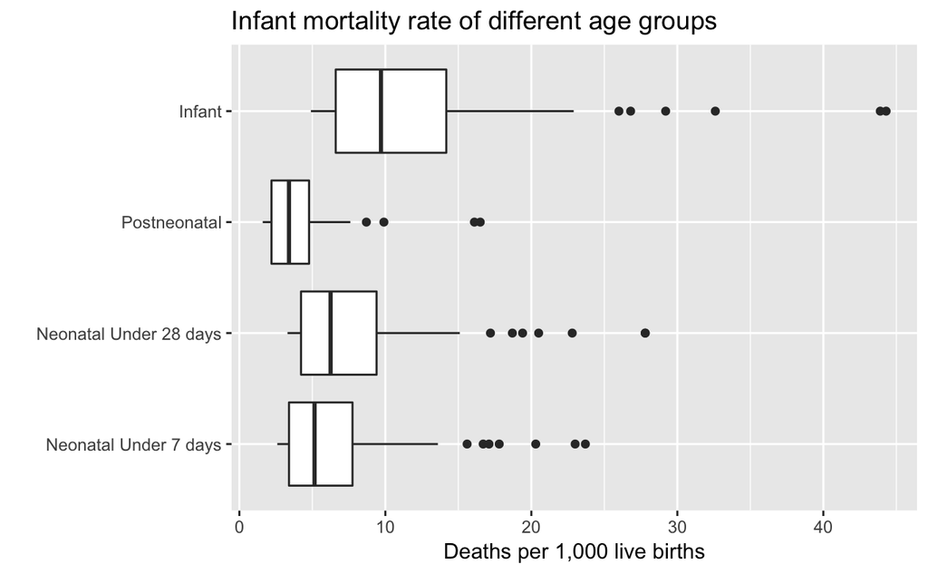

```r
library("ggplot2")
a = data.frame(group="Infant",value=data$Infant)
b = data.frame(group="Postneonatal", value=data$Postneonatal)
c = data.frame(group="Neonatal Under 28 days", value=data$`Neonatal1 Under 28 days`)
d = data.frame(group="Neonatal Under 7 days", value=data$`Neonatal1 Under 7 days`)
plotdata = rbind(d,c,b,a)
ggplot(data = plotdata, mapping = aes(x=group,y=value))+geom_boxplot()+coord_flip()+
  labs(title="Infant mortality rate of different age groups",y="Deaths per 1,000 live births", x = "")
```

```r
# Or use following boxplot command:
#boxplot(data$Infant, data$`Neonatal1 Under 28 days`, data$`Neonatal1 Under 7 days`, data$Postneonatal, names = c("Infant", "Neonatal1 Under 28 days","Neonatal1 Under 7 days","Postneonatal"),horizontal=TRUE,las=2, ylab = "Deaths per 1,000 live births")
```

From the boxplot of infant mortality rate above, we could see that the death rate of postneonatals has smaller value and narrower distribution than that of neonatals.

### 2.2. Difference in Mortality rate due to race

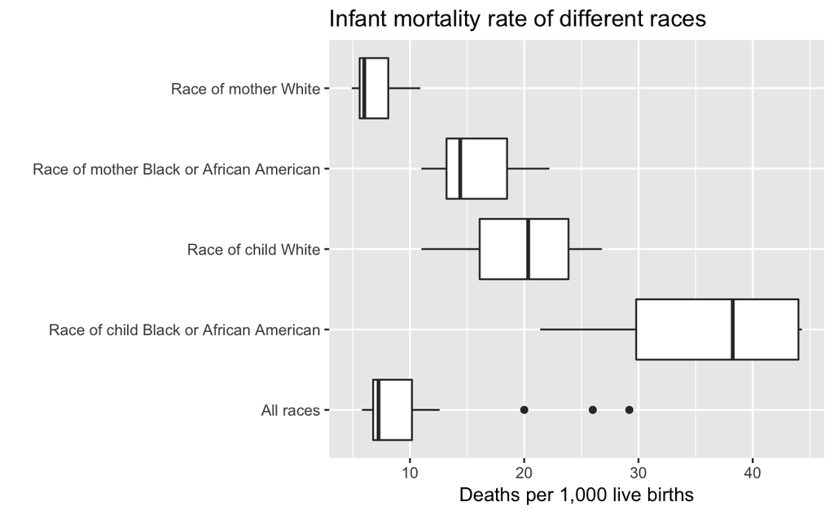

```r
ggplot(data = data, mapping = aes(x = data$race, y=data$Infant))+geom_boxplot()+coord_flip()+
  labs(title="Infant mortality rate of different races",y="Deaths per 1,000 live births", x = "")
```

From the boxplot of infant mortality rate of different races, we could find that:  
1) The white infants have lower death rate than black or African American infants.  
2) The infants born by white mothers have lower death rate than that by black or African American mothers.  
3) The death rate of black or African American infants is the highest among the five race groups and has the widest expansion.

It is reasonable to suggest there might be some correlation between the race of mother and that of child. The large difference between the death rate of black or African American infants and that of infants with black or African American mothers seems a little weird. This may due to the fact that data of different race groups are collected in different years.

### 2.3. Difference in Mortality rate due to time

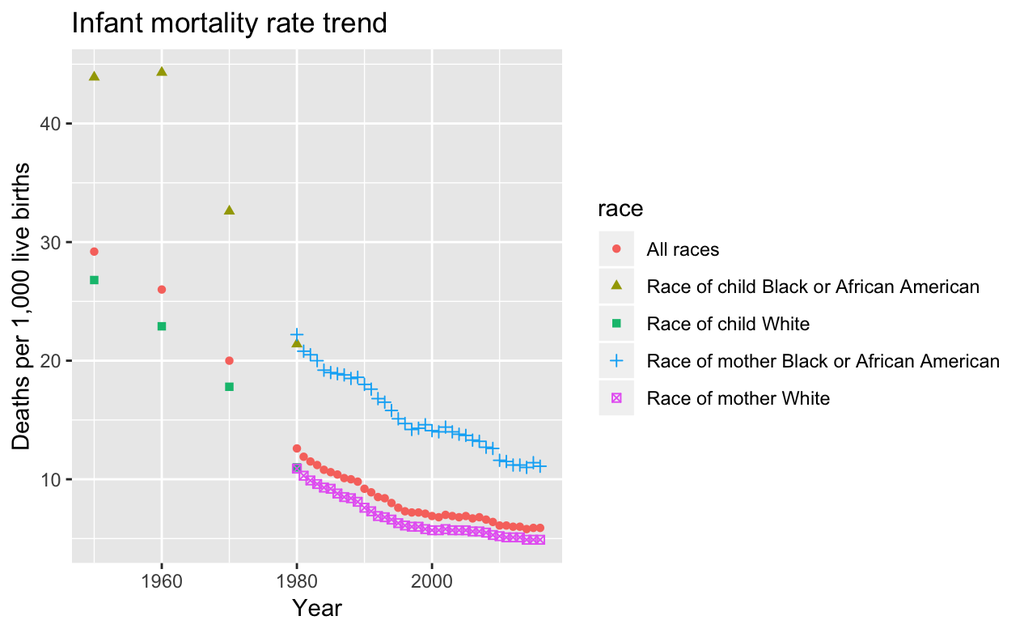

```r
ggplot(data, aes(x=Year, y=Infant, shape=race, color=race)) +
  geom_point()+
  labs(title="Infant mortality rate trend",y="Deaths per 1,000 live births")
```

From the scatter plot above, we could see that the infant mortality rate decreases with time and the decrease trend becomes flatter with time. And the trend is similar for different races while the infant mortality rate of white mother (or child) is less than that of black or African American mother (or child).

### 2.4. Infant mortality rate correlation between different races

```r
cor.test(data[data$race=='Race of mother White',]$Infant, data[data$race=='Race of mother Black or African American',]$Infant)
```

```
    Pearson's product-moment correlation

data:  data[data$race == "Race of mother White", ]$Infant and data[data$race == "Race of mother Black or African American", data[data$race == "Race of mother White", ]$Infant and     ]$Infant
t = 24.7592, df = 35, p-value < 2.2e-16
alternative hypothesis: true correlation is not equal to 0
95 percent confidence interval:
 0.9470662 0.9859267
sample estimates:
      cor
0.9726198
```

```r
cor.test(data[(data$race=='All races') & (data$Year>1979) ,]$Infant, data[data$race=='Race of mother Black or African American',]$Infant)
```

```
    Pearson's product-moment correlation

data:  data[(data$race == "All races") & (data$Year > 1979), ]$Infant and data[data$race == "Race of mother Black or African American", data[(data$race == "All races") & (data$Year > 1979), ]$Infant and     ]$Infant
t = 33.0071, df = 35, p-value < 2.2e-16
alternative hypothesis: true correlation is not equal to 0
95 percent confidence interval:
 0.9695058 0.9919607
sample estimates:
      cor
0.9843141
```

```r
cor.test(data[data$race=='Race of child White',]$Infant, data[data$race=='Race of child Black or African American',]$Infant)
```

```
    Pearson's product-moment correlation

data:  data[data$race == "Race of child White", ]$Infant and data[data$race == "Race of child Black or African American", data[data$race == "Race of child White", ]$Infant and     ]$Infant
t = 5.5312, df = 2, p-value = 0.03117
alternative hypothesis: true correlation is not equal to 0
95 percent confidence interval:
 0.1124995 0.9993720
sample estimates:
      cor
0.9688344
```

[^1]: Infant (aged < 1 year), neonatal (aged < 28 days), postneonatal (aged 28 days to 11 months). So the infant death number = the neonatal death number + the postneonatal death.